# Revisión de simulación energética

Autor

Guillermo Barrios

# Introduccion

En este reporte se revisa la simulación energética del archivo

`\.\./osm/CE\_CASA 3D\_270224/run/eplusout\.sql`.

Se revisa lo siguiente:

1. Zonas térmicas y temperaturas de las mismas.
2. Conteo de personas por zona térmica.
3. Cargas térmicas por equipo eléctrico.
4. Sistemas constructivos y materiales.

Las figuras presentadas corresponden del `2006\-01\-01 00:00:00` al `2006\-01\-08 00:00:00`.

## Zonas térmicas y temperaturas

La lista de zonas térmicas es:

`['Ti_BANIO', 'Ti_BANIOCOMPLETO', 'Ti_COCINAA', 'Ti_R1', 'Ti_R2', 'Ti_R3', 'Ti_SYP']`

Y la temperatura en las zonas térmicas se ve así:

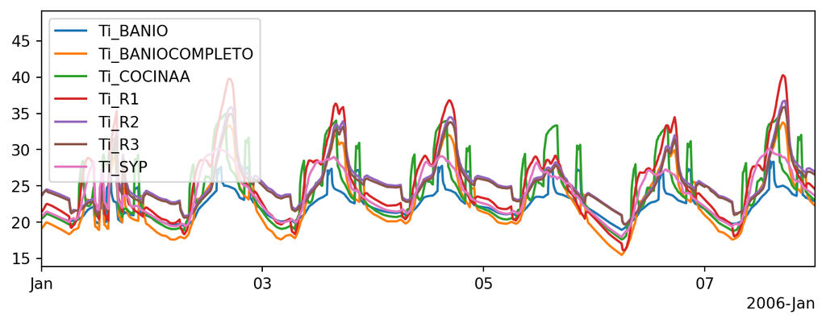

## Conteo de personas por zona térmica

La lista de zonas térmicas con personas es:

`['BANIO:Zone People Occupant Count ()', 'BANIOCOMPLETO:Zone People Occupant Count ()', 'COCINAA:Zone People Occupant Count ()', 'R1:Zone People Occupant Count ()', 'R2:Zone People Occupant Count ()', 'R3:Zone People Occupant Count ()', 'SYP:Zone People Occupant Count ()']`

Y la ocupación por zona térmica se ve así:

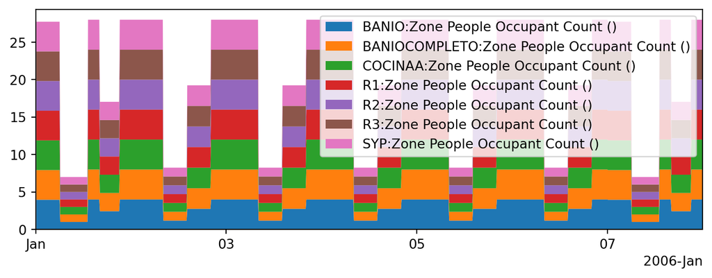

## Cargas térmicas por equipo eléctrico

La lista de equipo eléctrico en la simulación es:

`['ELECTRIC EQUIPMENT 1:Electric Equipment Electricity Rate (W)', 'ELECTRIC EQUIPMENT 2:Electric Equipment Electricity Rate (W)']`

Y las cargas térmicas se ven:

[figure not shown]

## Sistemas constructivos

**Trabajo pendiente**

Quarto tiene problemas para desplegar el código que va en esta parte, pero se puede ver en la libreta. Se debe arreglar la función get_construction para que no imprima, si no que regrese un DF.